[figure not shown]

### Prof. José Manuel Magallanes, PhD

- Associate Professor, Departamento de Ciencias Sociales, Pontificia Universidad Católica del Perú, jmagallanes@pucp.edu.pe
- Visiting Associate Professor, Evans School of Public Policy and Governance / Senior Data Science Fellow, eScience Institute, University of Washington, magajm@uw.edu

# Session 2: Introduction to R.

# The data frame in R

## Collecting data:

Let’s collect the file we created in Python:

```r
# the location
MyFile='https://github.com/eScienceUW-WinterSchool-2020/RSession/raw/master/hdidemocia.RDS'


# if location is website:
MyFile=url(MyFile)

# get the data:
fromPy=readRDS(file = MyFile) # no need for a library
row.names(fromPy)=NULL   # reset indexes from Python.
```

Always check the data types:

```r
str(fromPy)  # less space: width = 70,strict.width='cut'
```

```
## 'data.frame':    164 obs. of  16 variables:
##  $ Country                     : chr  "Norway" "Switzerland" "Ireland" "Germany" ...
##  $ Humandevelopmentindex       : num  0.954 0.946 0.942 0.939 0.939 0.938 0.938 0.937 0.935 0.933 ...
##  $ Lifeexpectancyatbirth       : num  82.3 83.6 82.1 81.2 84.7 83.3 82.9 82.7 83.5 82.1 ...
##  $ Expectedyearsofschooling    : num  18.1 16.2 18.8 17.1 16.5 22.1 19.2 18.8 16.3 18 ...
##  $ Meanyearsofschooling        : num  12.6 13.4 12.5 14.1 12 12.7 12.5 12.4 11.5 12.2 ...
##  $ Grossnationalincomepercapita: num  68059 59375 55660 46946 60221 ...
##  $ Score                       : chr  "9.87" "9.03" "9.24" "8.68" ...
##  $ Electoralprocessandpluralism: num  10 9.58 10 9.58 3.58 10 10 9.58 3.92 9.58 ...
##  $ Functioningofgovernment     : num  9.64 9.29 7.86 8.57 4.36 8.93 9.29 9.64 7.86 9.29 ...
##  $ Politicalparticipation      : num  10 7.78 8.33 8.33 6.11 7.78 8.89 8.33 5 8.33 ...
##  $ Politicalculture            : num  10 9.38 10 7.5 7.5 8.75 10 10 6.25 8.75 ...
##  $ Civilliberties              : num  9.71 9.12 10 9.41 8.53 10 9.71 9.41 7.06 9.12 ...
##  $ Regimetype                  : Ord.factor w/ 4 levels "Authoritarian"<..: 4 4 4 4 3 4 4 4 3 4 ...
##  $ Continent                   : Factor w/ 7 levels "Africa","Asia",..: 3 3 3 3 2 6 3 3 2 3 ...
##  $ countries                   : chr  "Norway" "Switzerland" "Ireland" "Germany" ...
##  $ co2_in_MT                   : num  3.98e+07 3.90e+07 3.69e+07 8.48e+08 1.02e+08 ...
```

## Querying data frames:

- What is the country with highest HDI?

```r
# you could get more than one
fromPy[fromPy$Humandevelopmentindex==max(fromPy$Humandevelopmentindex),]
```

```
##   Country Humandevelopmentindex Lifeexpectancyatbirth
## 1  Norway                 0.954                  82.3
##   Expectedyearsofschooling Meanyearsofschooling
## 1                     18.1                 12.6
##   Grossnationalincomepercapita Score Electoralprocessandpluralism
## 1                     68058.62  9.87                           10
##   Functioningofgovernment Politicalparticipation Politicalculture
## 1                    9.64                     10               10
##   Civilliberties     Regimetype Continent countries co2_in_MT
## 1           9.71 Full democracy    Europe    Norway  39800000
```

```r
#or
fromPy[fromPy$Humandevelopmentindex==max(fromPy$Humandevelopmentindex),'Country']
```

```
## [1] "Norway"
```

You also have:

```r
#or
fromPy[which.max(fromPy$Humandevelopmentindex),'Country']
```

```
## [1] "Norway"
```

- What is the country with highest HDI in America?

```r
# from AMERICA:
AMERICA=c('South America','North America')
subAmerica=fromPy[fromPy$Continent %in% AMERICA,]
subAmerica[which.max(subAmerica$Humandevelopmentindex),'Country']
```

```
## [1] "Canada"
```

```r
library(magrittr)
library(dplyr)
fromPy%>%
    filter(Continent %in% AMERICA)%>%
    filter(Humandevelopmentindex==max(Humandevelopmentindex))%>%
    select(Country)
```

```
##   Country
## 1  Canada
```

- What is the country with highest HDI not from America?

```r
# from AMERICA:
AMERICA=c('South America','North America')
subNotAmerica=fromPy[!fromPy$Continent %in% AMERICA,]
subNotAmerica[which.max(subNotAmerica$Humandevelopmentindex),'Country']
```

```
## [1] "Norway"
```

```r
fromPy%>%
    filter(!Continent %in% AMERICA)%>%
    filter(Humandevelopmentindex==max(Humandevelopmentindex))%>%
    select(Country)
```

```
##   Country
## 1  Norway
```

## Aggregating data frames:

The average HDI per continent:

```r
aggregate(data=fromPy,Humandevelopmentindex ~ Continent,FUN=mean)
```

```
##       Continent Humandevelopmentindex
## 1        Africa             0.5481400
## 2          Asia             0.7280000
## 3        Europe             0.8692895
## 4   Europe/Asia             0.7974000
## 5 North America             0.7386429
## 6       Oceania             0.7815000
## 7 South America             0.7559167
```

```r
fromPy%>%
    group_by(Continent) %>%
    summarise(meanHDI = mean(Humandevelopmentindex))
```

```
## # A tibble: 7 x 2
##   Continent     meanHDI
##   <fct>           <dbl>
## 1 Africa          0.548
## 2 Asia            0.728
## 3 Europe          0.869
## 4 Europe/Asia     0.797
## 5 North America   0.739
## 6 Oceania         0.782
## 7 South America   0.756
```

The median of the democracy components:

```r
aggregate(data=fromPy,
          cbind(Electoralprocessandpluralism,Functioningofgovernment,
                Politicalparticipation,Politicalculture,
                Civilliberties)~Continent,
          FUN=median)
```

```
##       Continent Electoralprocessandpluralism Functioningofgovernment
## 1        Africa                         3.50                   2.895
## 2          Asia                         3.92                   4.290
## 3        Europe                         9.58                   6.965
## 4   Europe/Asia                         2.17                   3.210
## 5 North America                         8.96                   5.715
## 6       Oceania                         8.46                   7.500
## 7 South America                         9.17                   5.360
##   Politicalparticipation Politicalculture Civilliberties
## 1                  4.440            5.315          4.120
## 2                  4.440            5.000          4.120
## 3                  6.670            6.880          8.530
## 4                  5.000            4.380          3.530
## 5                  6.110            5.315          7.060
## 6                  6.945            6.880          8.825
## 7                  5.835            5.000          7.650
```

```r
aggregate(data=fromPy[,c(8:12,14)],.~Continent,FUN=median)
```

```
##       Continent Electoralprocessandpluralism Functioningofgovernment
## 1        Africa                         3.50                   2.895
## 2          Asia                         3.92                   4.290
## 3        Europe                         9.58                   6.965
## 4   Europe/Asia                         2.17                   3.210
## 5 North America                         8.96                   5.715
## 6       Oceania                         8.46                   7.500
## 7 South America                         9.17                   5.360
##   Politicalparticipation Politicalculture Civilliberties
## 1                  4.440            5.315          4.120
## 2                  4.440            5.000          4.120
## 3                  6.670            6.880          8.530
## 4                  5.000            4.380          3.530
## 5                  6.110            5.315          7.060
## 6                  6.945            6.880          8.825
## 7                  5.835            5.000          7.650
```

```r
fromPy[,c(8:12,14)]%>%
    group_by(Continent) %>%
    summarise_all(list(median))
```

```
## # A tibble: 7 x 6
##   Continent Electoralproces… Functioningofgo… Politicalpartic…
##   <fct>                <dbl>            <dbl>            <dbl>
## 1 Africa                3.5              2.90             4.44
## 2 Asia                  3.92             4.29             4.44
## 3 Europe                9.58             6.96             6.67
## 4 Europe/A…             2.17             3.21             5
## 5 North Am…             8.96             5.72             6.11
## 6 Oceania               8.46             7.5              6.94
## 7 South Am…             9.17             5.36             5.84
## # … with 2 more variables: Politicalculture <dbl>, Civilliberties <dbl>
```

## Creating new data:

One column:

```r
fromPy$HDIdico=ifelse(fromPy$Humandevelopmentindex>
                          median(fromPy$Humandevelopmentindex),
                      1,0)
```

A new data frame:

```r
fromPy%>%
    mutate(HDIdico = ifelse(Humandevelopmentindex>median(Humandevelopmentindex),
                            1, 0))%>%
    select(Country,HDIdico)
```

```
##                               Country HDIdico
## 1                              Norway       1
## 2                         Switzerland       1
## 3                             Ireland       1
## 4                             Germany       1
## 5                           Hong Kong       1
## 6                           Australia       1
## 7                             Iceland       1
## 8                              Sweden       1
## 9                           Singapore       1
## 10                        Netherlands       1
## 11                            Denmark       1
## 12                            Finland       1
## 13                             Canada       1
## 14                        New Zealand       1
```

[output cut: 150 more lines]

## Unsupervised ML: Dimensionality Reduction

You would like turn the 5 dimensions into one, without following an arithmetic approach, but an algebraic one, instead. Dimension reduction is the job of latent variable analysis, and that’s the way proposed here.

Let me subset our original data frame:

```r
subDemo=fromPy[,c(8:12)]
```

Our *subDemo* DF has the data to compute the one index we need. Let me use a technique called **confirmatory factor analysis**:

```r
names(subDemo)
```

```
## [1] "Electoralprocessandpluralism" "Functioningofgovernment"
## [3] "Politicalparticipation"       "Politicalculture"
## [5] "Civilliberties"
```

```r
library(lavaan)
model='
democracy=~Electoralprocessandpluralism + Functioningofgovernment + Politicalparticipation + Politicalculture + Civilliberties
'

fitNUM<-cfa(model, data = subDemo,std.lv=TRUE)
indexCFA=lavPredict(fitNUM)
```

The index computed is not in a range from 1 to 10:

```r
head(indexCFA,20)
```

```
##       democracy
##  [1,] 1.6744212
##  [2,] 1.3876739
##  [3,] 1.5619455
##  [4,] 1.3862248
##  [5,] 0.4997853
##  [6,] 1.5620413
##  [7,] 1.6043355
##  [8,] 1.5085845
##  [9,] 0.3190209
## [10,] 1.3967604
## [11,] 1.4391359
## [12,] 1.5526025
## [13,] 1.5299201
## [14,] 1.6166464
## [15,] 1.2936598
## [16,] 1.0135757
## [17,] 1.0132113
## [18,] 1.1153096
## [19,] 1.2085246
## [20,] 1.4502184
```

We force its return to 0 to 10:

```r
library(BBmisc)
indexCFANorm=normalize(indexCFA,
                       method = "range",
                       margin=2, # by column
                       range = c(0, 10))
```

So, this is our index:

```r
fromPy$dem_FA=as.vector(indexCFANorm)
```

Let me plot the new variable

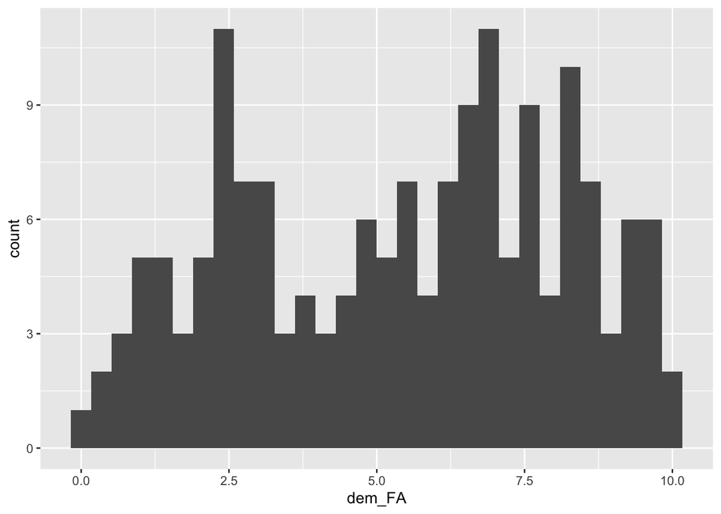

```r
library(ggplot2)

base=ggplot(data=fromPy)
base + geom_histogram(aes(x=dem_FA))
```

Or:

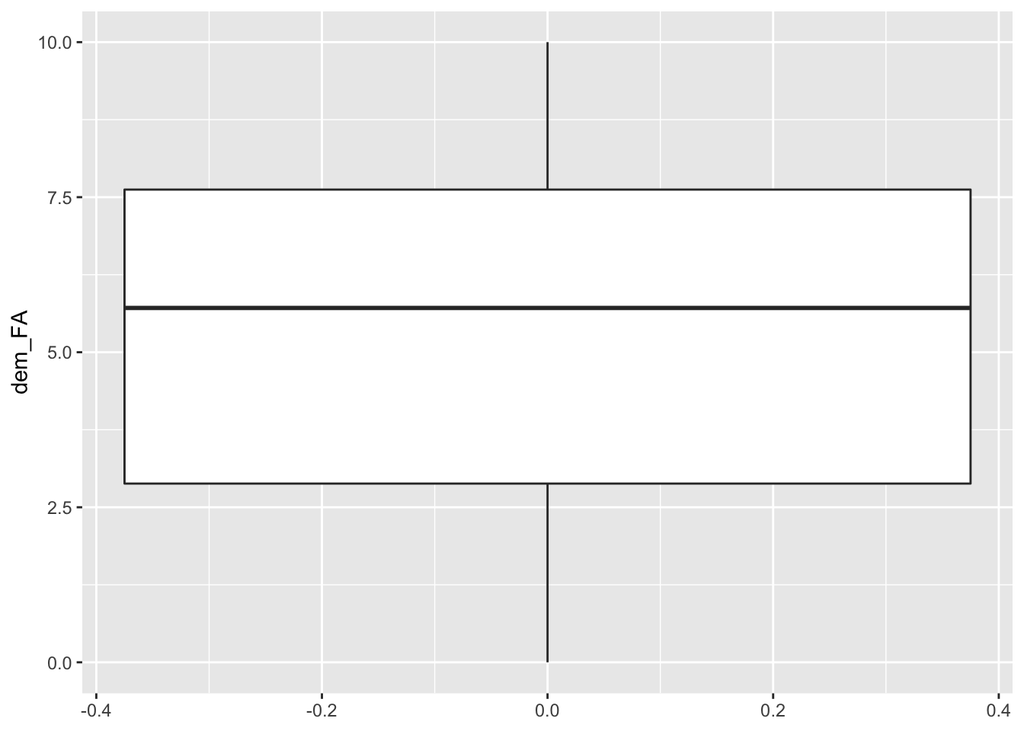

```r
base + geom_boxplot(aes(y=dem_FA))
```

Let me see some evaluation measures of our index for democracy:

```r
evalCFA1=parameterEstimates(fitNUM, standardized =TRUE)
```

- Loadings

```
##                            rhs std.all pvalue
## 1 Electoralprocessandpluralism   0.927      0
## 2      Functioningofgovernment   0.882      0
## 3       Politicalparticipation   0.820      0
## 4             Politicalculture   0.677      0
## 5               Civilliberties   0.970      0
```

- Some coefficients:
- You want p.value greater than 0.05:

```r
evalCFA2[c("chisq", "df", "pvalue")]
```

```
## $chisq
## [1] 34.6731
##
## $df
## [1] 5
##
## $pvalue
## [1] 1.748432e-06
```

- You want the Tucker-Lewis > 0.9:

```
## [1] 0.9244438
```

- You want RMSEA < 0.05:

```
## $rmsea.ci.lower
## [1] 0.1335023
##
## $rmsea
## [1] 0.190228
##
## $rmsea.ci.upper
## [1] 0.2523378
```

You can see how it looks:

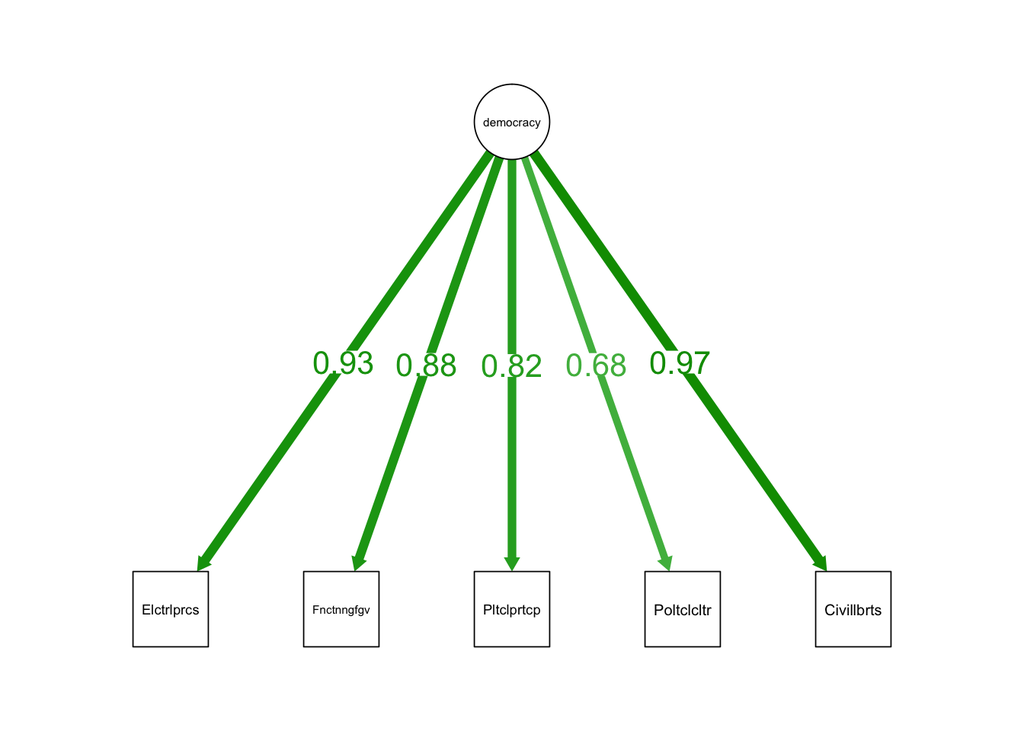

## Unsupervised ML: Clustering via partitioning

### Part 1: Preparing data

**a.** Subset the data frame:

```r
dfClus=fromPy[,c(2,13,16)]
```

**b.** Rename the rows:

```r
#from
head(dfClus)
```

```
##   Humandevelopmentindex       Regimetype co2_in_MT
## 1                 0.954   Full democracy  39800000
## 2                 0.946   Full democracy  38950000
## 3                 0.942   Full democracy  36910000
## 4                 0.939   Full democracy 847600000
## 5                 0.939 Flawed democracy 102500000
## 6                 0.938   Full democracy 439100000
```

```r
#to
row.names(dfClus)=fromPy$Country
head(dfClus)
```

```
##             Humandevelopmentindex       Regimetype co2_in_MT
## Norway                      0.954   Full democracy  39800000
## Switzerland                 0.946   Full democracy  38950000
## Ireland                     0.942   Full democracy  36910000
## Germany                     0.939   Full democracy 847600000
## Hong Kong                   0.939 Flawed democracy 102500000
## Australia                   0.938   Full democracy 439100000
```

**c.** Keep only complete data:

```r
dfClus=dfClus[complete.cases(dfClus),]
```

**d.** Decide distance method and compute distance matrix:

```r
library(cluster)
dfClus_D=cluster::daisy(x=dfClus,metric="gower")
```

### Part 2: Clustering process

### 1. Apply function: you need to indicate the amount of clusters required.

```r
set.seed(123)
numberOfClusters=4
res.pam = pam(x=dfClus_D,k = numberOfClusters,cluster.only = F)
```

### 2. Save clustering results.

```r
fromPy$pam=as.factor(res.pam$clustering)
```

You can see who are the members:

```r
fromPy[fromPy$pam==1,'Country']
```

```
##  [1] "Norway"         "Switzerland"    "Ireland"        "Germany"
##  [5] "Australia"      "Iceland"        "Sweden"         "Netherlands"
##  [9] "Denmark"        "Finland"        "Canada"         "New Zealand"
## [13] "United Kingdom" "Austria"        "Luxembourg"     "Spain"
## [17] "France"         "Portugal"       "Chile"          "Uruguay"
## [21] "Mauritius"      "Costa Rica"
```

You can request belonging:

```r
fromPy[fromPy$Country=="Peru",'pam']
```

```
## [1] 2
## Levels: 1 2 3 4
```

### 3. Evaluate Results.

**3.a** Global Report

```r
pamEval=as.data.frame.array(silhouette(res.pam))
pamEval$country=row.names(pamEval)
row.names(pamEval)=NULL
aggregate(data=pamEval,sil_width~cluster,FUN=mean)
```

```
##   cluster sil_width
## 1       1 0.8056120
## 2       2 0.4918510
## 3       3 0.4734993
## 4       4 0.5291130
```

**3.b** Individual report

```r
head(pamEval)
```

```
##   cluster neighbor sil_width     country
## 1       1        2 0.8729713     Finland
## 2       1        2 0.8722811 New Zealand
## 3       1        2 0.8717713     Denmark
## 4       1        2 0.8676382      Sweden
## 5       1        2 0.8662296     Austria
## 6       1        2 0.8637618     Iceland
```

**3.c** Detecting anomalies

```r
pamEval[pamEval$sil_width<0,]
```

```
##     cluster neighbor   sil_width          country
## 74        2        4 -0.16389921           Turkey
## 75        2        4 -0.16780333       Montenegro
## 76        2        4 -0.25575833          Albania
## 164       4        2 -0.04088538 Papua New Guinea
```

```r
pamEval_O=pamEval[order(pamEval$cluster,pamEval$sil_width),]
```

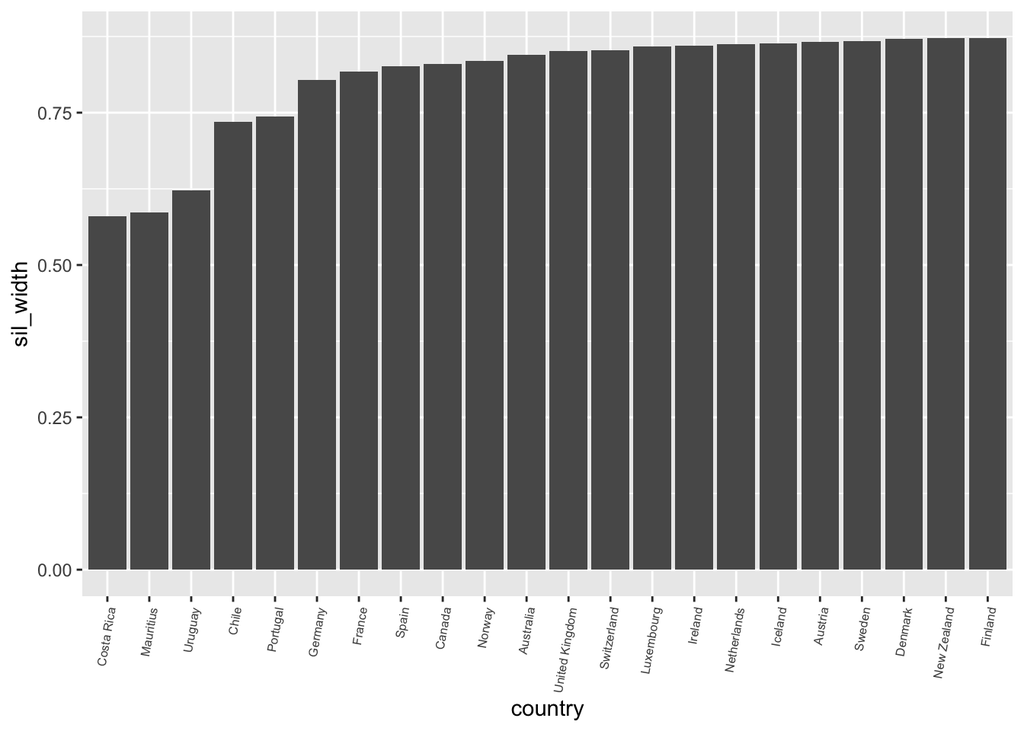

```r
clusterVal=1
pamEval=pamEval_O[pamEval_O$cluster==clusterVal,]

base=ggplot(data=pamEval,
             aes(x=country,
                 y=sil_width))
sil1= base + geom_bar(stat='identity')
sil1= sil1 + scale_x_discrete(limits=pamEval$country)
sil1= sil1 + theme(axis.text.x = element_text(angle = 80,
                                              size = 6,
                                              hjust = 1))
sil1
```

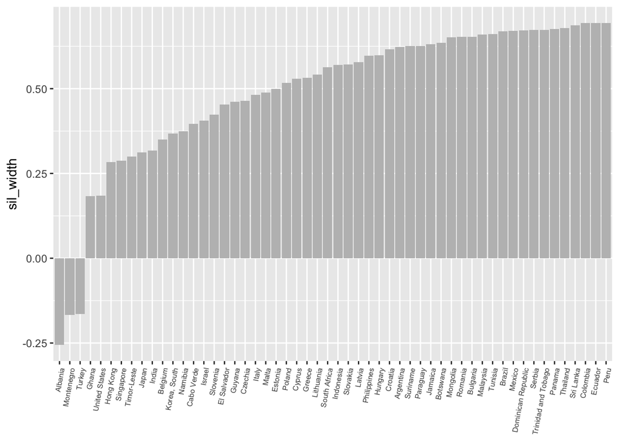

```r
clusterVal=2
pamEval=pamEval_O[pamEval_O$cluster==clusterVal,]

base=ggplot(data=pamEval,
             aes(x=country,
                 y=sil_width))
sil2= base + geom_bar(stat='identity',fill='grey')
sil2= sil2 + scale_x_discrete(limits=pamEval$country)
sil2= sil2 + theme(axis.text.x = element_text(angle = 80,
                                              size = 6,
                                              hjust = 1))
sil2= sil2 + labs(x=NULL)
sil2
```

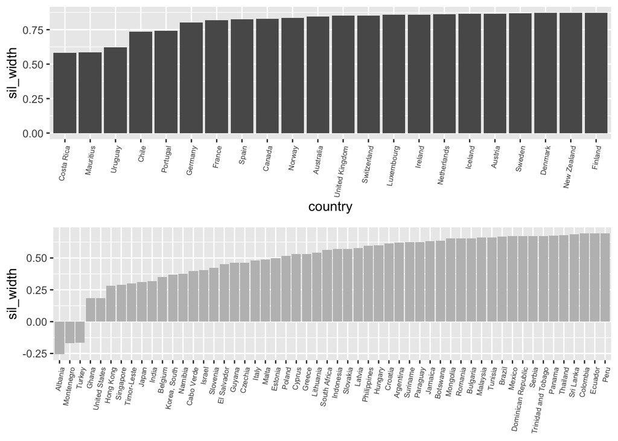

```r
library(ggpubr)

ggarrange(sil1,sil2,ncol = 1)
```

We should see how the world likes like based on democracy clusters, follow this steps:

1. Download the world map from [here](https://github.com/eScienceUW-WinterSchool-2020/RSession/raw/master/map/world_map.zip).
2. Unzip the file you downloaded in a folder.
3. Upload the unzipped files into [MAPSHAPER](https://mapshaper.org/). No need to uplod the text file.
4. Transform the map into a TOPOJSON format. Save the topojson into your computer.
5. Get a github account. Create a repository and upload the topojson file.
6. Get the download link and use it in the next code.

```r
# installed?
#library(sp)
#library(geojsonio)
library(rgdal)
```

```r
fromGit="https://github.com/eScienceUW-WinterSchool-2020/RSession/raw/master/map/world_map.json" # link desde github


mapWorld <- rgdal::readOGR(fromGit,stringsAsFactors = FALSE)
```

We have the map:

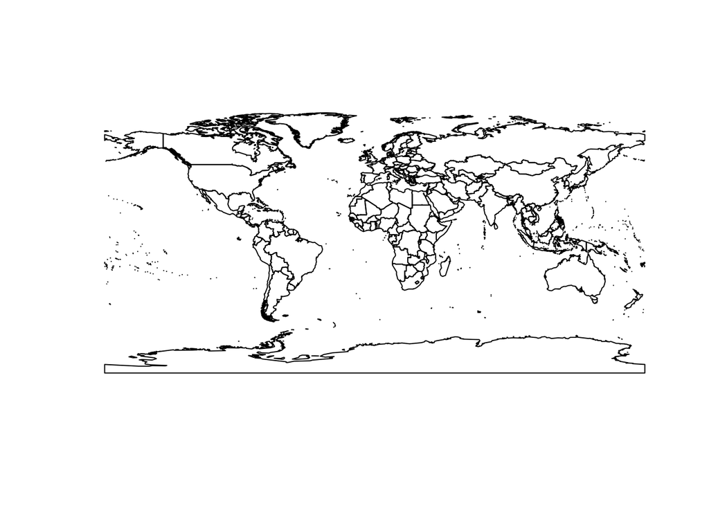

```r
plot(mapWorld)
```

The plan is to color the countries according to a group, which will result from clustering.

```r
# see data in map
head(mapWorld@data)
```

```
##     id FIPS ISO2 ISO3 UN                NAME   AREA  POP2005 REGION
## 0 <NA>   AC   AG  ATG 28 Antigua and Barbuda     44    83039     19
## 1 <NA>   AG   DZ  DZA 12             Algeria 238174 32854159      2
## 2 <NA>   AJ   AZ  AZE 31          Azerbaijan   8260  8352021    142
## 3 <NA>   AL   AL  ALB  8             Albania   2740  3153731    150
## 4 <NA>   AM   AM  ARM 51             Armenia   2820  3017661    142
## 5 <NA>   AO   AO  AGO 24              Angola 124670 16095214      2
##   SUBREGION     LON     LAT
## 0        29 -61.783  17.078
## 1        15   2.632  28.163
## 2       145  47.395  40.430
## 3        39  20.068  41.143
## 4       145  44.563  40.534
## 5        17  17.544 -12.296
```

Let’s add our data to the map data:

```r
mapWorldAll=merge(mapWorld, #map first
                   fromPy,
                   by.x='NAME', # common column
                   by.y='Country', # common column
                   all.x=F) # reduced map.
```

Now paint the world (get colors from [here](http://colorbrewer2.org/)):

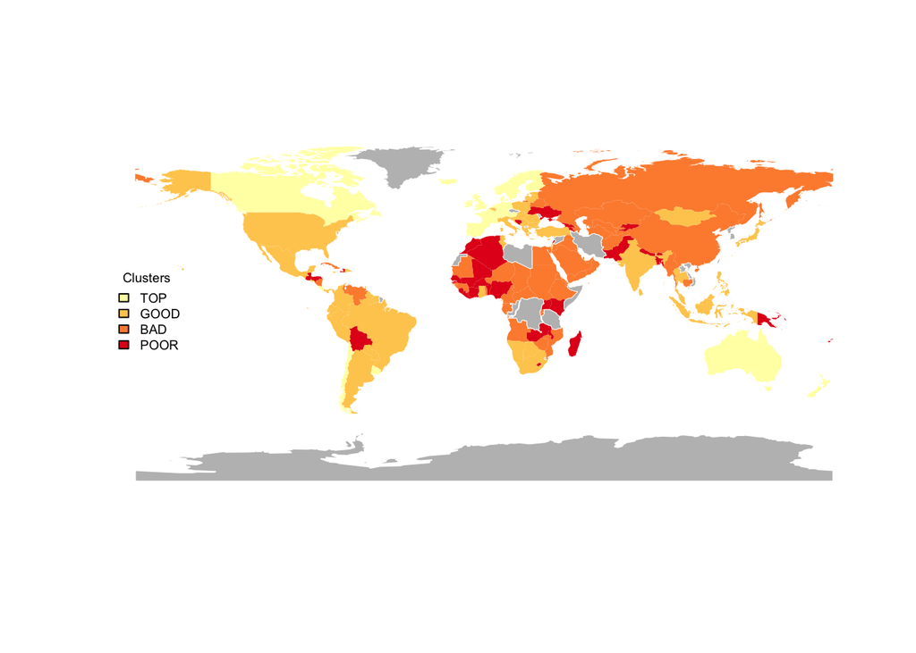

```r
# what:
varToPlot=mapWorldAll$pam

#which colors:
library(RColorBrewer)
colorForScale='YlOrRd'
palette = brewer.pal(numberOfClusters, colorForScale)

# plotting:

## base layer - coloring missing data
plot(mapWorld,col='grey',border=0)

## top layer
plot(mapWorldAll, col = palette[varToPlot],border=F,add=T)


legend('left', legend = c("TOP","GOOD","BAD","POOR"),
       fill = palette,
       cex = 0.6,
       bty = "n",
       title="Clusters")
```

## Regression

This may be the easiest functions:

```r
# hypothesis 1:

# The more democratic and the better HDI
# the less contaminated a country is,
# controlling continent
#row.names(fromPy)=fromPy$Country
hypo1=formula(co2_in_MT~ dem_FA + Humandevelopmentindex + Continent)
regre1=glm(hypo1,data = fromPy,family = 'gaussian')
```

```r
summary(regre1)
```

```
##
## Call:
## glm(formula = hypo1, family = "gaussian", data = fromPy)
##
## Deviance Residuals:
##        Min          1Q      Median          3Q         Max
## -8.157e+08  -2.739e+08  -8.308e+07   4.644e+07   1.095e+10
##
## Coefficients:
##                          Estimate Std. Error t value Pr(>|t|)
## (Intercept)            -829007331  466553281  -1.777   0.0776 .
## dem_FA                  -55185740   44477427  -1.241   0.2166
## Humandevelopmentindex  1955728898  912923575   2.142   0.0337 *
## ContinentAsia           138778032  266712309   0.520   0.6036
## ContinentEurope        -323454124  339433099  -0.953   0.3421
## ContinentEurope/Asia    -32939484  533771188  -0.062   0.9509
## ContinentNorth America  207887870  344123859   0.604   0.5467
## ContinentOceania       -138733056  564956259  -0.246   0.8063
## ContinentSouth America -167920320  369028742  -0.455   0.6497
## ---
## Signif. codes:  0 '***' 0.001 '**' 0.01 '*' 0.05 '.' 0.1 ' ' 1
##
## (Dispersion parameter for gaussian family taken to be 1.030149e+18)
##
##     Null deviance: 1.7159e+20  on 163  degrees of freedom
## Residual deviance: 1.5967e+20  on 155  degrees of freedom
## AIC: 7278.3
##
## Number of Fisher Scoring iterations: 2
```

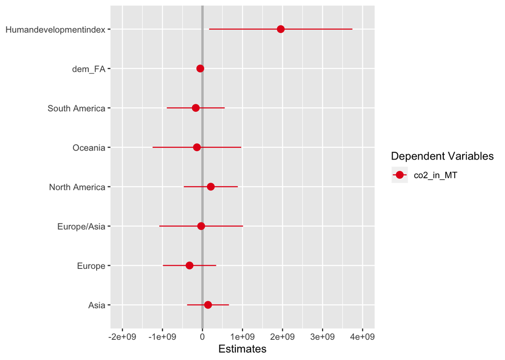

```r
library(sjPlot)
plot_models(regre1,vline.color = "grey")
```

```r
# hypothesis 2:

# The democracy and level of contamination
# affect  the leve level of human development,
# controlling continent

hypo2=formula(HDIdico~ dem_FA + co2_in_MT + Continent)
regre2=glm(hypo2,data = fromPy,family = "binomial")
```

```r
summary(regre2)
```

```
##
## Call:
## glm(formula = hypo2, family = "binomial", data = fromPy)
##
## Deviance Residuals:
##      Min        1Q    Median        3Q       Max
## -2.52963  -0.44519  -0.07166   0.28966   2.52161
##
## Coefficients:
##                          Estimate Std. Error z value Pr(>|z|)
## (Intercept)            -4.685e+00  8.848e-01  -5.294 1.19e-07 ***
## dem_FA                  4.046e-01  1.157e-01   3.498 0.000469 ***
## co2_in_MT               5.772e-10  6.794e-10   0.850 0.395570
## ContinentAsia           2.747e+00  7.333e-01   3.746 0.000179 ***
## ContinentEurope         5.301e+00  1.207e+00   4.393 1.12e-05 ***
## ContinentEurope/Asia    2.070e+01  1.730e+03   0.012 0.990453
## ContinentNorth America  2.233e+00  8.622e-01   2.590 0.009598 **
## ContinentOceania        1.390e+00  1.276e+00   1.089 0.276153
## ContinentSouth America  2.149e+00  8.854e-01   2.428 0.015196 *
## ---
## Signif. codes:  0 '***' 0.001 '**' 0.01 '*' 0.05 '.' 0.1 ' ' 1
##
## (Dispersion parameter for binomial family taken to be 1)
##
##     Null deviance: 227.35  on 163  degrees of freedom
## Residual deviance: 111.15  on 155  degrees of freedom
## AIC: 129.15
##
## Number of Fisher Scoring iterations: 16
```

```r
# interpracion usando marginal effects:
library(margins)
#
(model = margins(regre2))
```

```
## Average marginal effects
```

```
## glm(formula = hypo2, family = "binomial", data = fromPy)
```

```
##   dem_FA co2_in_MT ContinentAsia ContinentEurope ContinentEurope/Asia
##  0.04361 6.221e-11        0.4415          0.7885               0.8709
##  ContinentNorth America ContinentOceania ContinentSouth America
##                  0.3434           0.1882                 0.3274
```

```r
(margins=summary(model))
```

```
##                  factor    AME     SE       z      p   lower  upper
##               co2_in_MT 0.0000 0.0000  1.4512 0.1467 -0.0000 0.0000
##           ContinentAsia 0.4415 0.0918  4.8113 0.0000  0.2616 0.6213
##         ContinentEurope 0.7885 0.1024  7.7020 0.0000  0.5879 0.9892
##    ContinentEurope/Asia 0.8709 0.0614 14.1855 0.0000  0.7506 0.9912
##  ContinentNorth America 0.3434 0.1329  2.5842 0.0098  0.0830 0.6038
##        ContinentOceania 0.1882 0.2010  0.9363 0.3491 -0.2057 0.5820
##  ContinentSouth America 0.3274 0.1389  2.3566 0.0184  0.0551 0.5997
##                  dem_FA 0.0436 0.0099  4.3910 0.0000  0.0241 0.0631
```

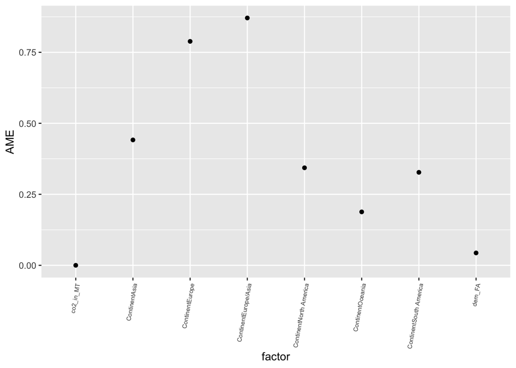

```r
base= ggplot(margins,aes(x=factor, y=AME)) + geom_point()
plot2 = base + theme(axis.text.x = element_text(angle = 80,
                                              size = 6,
                                              hjust = 1))
plot2
```

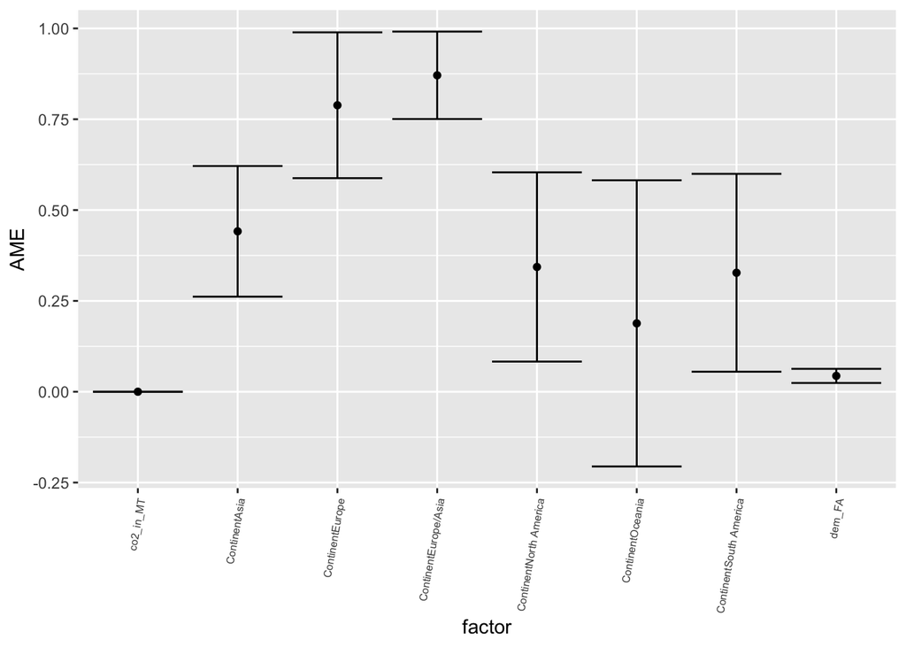

```r
plot2 +  geom_errorbar(aes(ymin=lower, ymax=upper))
```